# 版权信息

## **11.5 方法 3：闭包**

### **什么是闭包**

说到闭包（closure）这个概念，想必很多人一时也说不出究竟何为闭包。它是创建具有对象性质的事物的一种技术。

很多语言都支持定义带有某种状态的函数。比如，可以定义像计数器一样每调用一次显示的数字加 1 的函数。我们用 JavaScript 语言来实现一下。

```
 JavaScript
function makeCounter(){
  var count = 0;
  function push(){
    count++;
    console.log(count);
  }
  return push;
}

c = makeCounter();
c();                //-> 1
c();                //-> 2
c();                //-> 3
```

这段代码中，函数 makeCounter 中定义了变量 count 和函数 push，并返回函数 push。然后，通过调用函数 makeCounter 将返回值赋给变量 c，然后调用它三次。每调用一次，显示的值就加 1。这是怎么做到的呢？函数 makeCounter 首先创建了一张名字和值的对照表，把变量 count 的值设为 0。然后定义了函数 push，并将其返回。函数 push 将其被定义时的对照表一同带出 makeCounter 函数。随后，每当被调用时，函数 push 在被定义时的对照表的值就加 1。

事实上，并没有所谓闭包的特殊的语法结构。如果有一种语言 14，它可以在函数中定义函数，有允许嵌套的静态作用域，并且可以把函数作为返回值传递给变量，那么它只要通过函数的嵌套就可以实现带有某种状态的函数。

14大部分的函数式语言和 JavaScript 语言以及 Python 语言都满足这一条件。Perl 语言和 Ruby 语言经过一些处理也可以符合这一要求。

### **为什么叫做闭包**

看到闭包这个名字，总有一种什么东西被严实地包裹起来了的感觉。为什么会叫做闭包呢？某 Standard ML 的教材上做了如下解释。

> 为什么把这称为闭包？一个包含了自由变量的开放表达式，它和该自由变量的约束环境组合在一起后，实现了一种封闭的状态。

> ── Åke Wikström, *Functional programming using standard ML, Prentice-Hall*, 1987.15

15原文是“The reason it is called a‘closure’is that an expression containing free variables is called an‘open’expression, and by associating to it the bindings of its free variables, you close it”。

拿上面一段代码来讲，函数 push 使用了变量 count，然而该变量并不是在函数 push 中定义的。这种变量被称为自由变量。函数 push 就是一个包含了自由变量的开放函数。而函数 makeCounter 的对照表中为 0 的值和为 count 的名字结合在了一起。这种给值绑定一个名字的操作叫做（名字）约束。这样开放函数 push 和 makeCounter 的对照表组合配套之后，无需在这以外的作用域中寻找变量的定义，从而达到了某种完备的状态。通过这样表现出一种封闭的属性。

## **11.6 方法 4：类**

那么，何为类？它是语言设计者在特定语言中规定的一些称呼，具有多种定义。

### **霍尔设想的类**

首先来看原始形态的类是怎么定义的。1965 年霍尔在 ALGOL 的扩展方案中写道：“基于便利性的考虑，现在世界中的物（objects）通常被分为几种独立的分类，而某种分类的物如能进一步分为更细的类别（subclasses）就更方便了 16。”

16这是从“RECORD HANDLING”第 3 页和第 15 页翻译而来的。

从这段话能看出来，他所谓的类就是分类。它和我们日常说的 economy class（经济舱）中的 class 以及分组对抗赛中的分组属于相同的用法。现在 C++ 语言和 Java 语言中使用的 class 一词被追加了很多意思变得复杂起来，但最初都是分类的意思。现在所说的类的继承以及类是像做鲷鱼烧一样创建实例的鲷鱼烧的模具，这些说法都是后来才出来的概念。

### **C++ 语言中的类**

> 类是类型。这是 C++ 语言中极为重要的一种思想。既然 C++ 语言中类的意思就是用户定义的类型，那为什么不把它叫做 type 呢？我之所以选择使用 class，是因为实在不喜欢不断地创造新词，才选用 Simula 语言中 class 这个谁都不至于困惑的词。

> ——斯特劳斯特卢普《C++ 语言的设计与演化》

能让用户定义新的、操作起来如同 int 和 float 这样内置型的类型，这是 C++ 语言中引入类的目的。C 语言中也有能将各种变量归集到一起定义新的结构体的功能。C with Classes 中的类最初就是 C 语言中的结构体。之后，斯特劳斯特卢普把他认为好用的功能陆续加入了进来。其中之一就是功能说明的作用。

### **功能说明的作用**

对于 C++ 语言来讲，类( ＝类型 )也是功能说明的一种表现形式。也就是说，类起着一种作用，它可以声明对象具有哪些方法和不具有哪些方法。如果程序调用了不存在的方法会导致编译错误。这也是 Smalltalk 语言和 C++ 语言一个很大的区别 18。

18请参考：斯特劳斯特卢普,“What is Object-Oriented Programming? (1991 revised version)”, 1991, p.15. http://www.stroustrup.com/whatis.pdf。

在 Smalltalk 语言中，方法的调用就是向对象传送一个消息，告诉它去执行某某名字的方法。至于对象接收到这个消息后如何响应（执行什么操作还是导致错误还是不作任何处理），这可以由接收方的对象自由决定。Smalltalk 语言的设计者同时也是面向对象一词的发明者的艾伦·凯认为，这样的自由度是面向对象的重要元素之一。

### **类的三大作用**

大家是不是觉得类这个概念很复杂？的确如此。这是因为 C++ 语言和 Java 语言的类具有以下几个作用：

❶ 整合体的生成器

❷ 可行操作的功能说明

❸ 代码再利用的单位

Perl 语言和 JavaScript 语言的说明主要集中在生成器的功能方面。类是制作鲷鱼烧用的模具这一说法讲的就是这个作用。

第 12 章我们将探讨作用代码再利用的单位的类的作用，即继承 19。

19当然，并不是说现在的 Perl 语言和 C++ 语言中类作为代码再利用的单元的作用消失了，只是类在不同语言中发挥的这种作用有强弱之别。另外，至少在早期 Perl 语言的包中并不具有继承功能。

## **11.7 小结**

本章我们学习了面向对象产生的原因，它是为了创建现实世界中物的模型而产生的。同时，我们了解到，不同语言中类的实现方式以及面向对象这一术语本身的意义也是不同的。

# **第 12 章 继承与代码再利用**

> 本章我们来学习继承。

> 继承这一机制也是因语言而异。

> 我们将在不同语言的继承机制的比较中来认识它们各自的长处与短处。

## **12.1 什么是继承**

如第 11 章所述，类的最基本作用是分类。同一类别的事物具有共同的属性。即使将分类进一步细化，这些属性还是会被继承下去。

假设你要设计一个射击类的游戏。游戏中出场的角色为具有位置和头像的模型，并且进一步可以分类为由人操纵的己方角色和由计算机操纵的敌方角色。当然，己方角色和敌方角色都一样，具有位置和头像的属性。可见分类进一步细化后属性得到了继承。

己方角色和敌方角色在实际实现中，分别声明各自的位置和头像属性将是一个重复工作。如果类中已经声明的属性能在对其进一步细分的子类 1 中自动传承，这种语言的功能是非常好的。因此，继承产生了（图 12.1）。

1子类（subclass）是从其他类中继承而创建的类。类 Y 从类 X 继承得到，就可以说类 Y 是类 X 的子类。子类的反义词是父类（superclass）。Y 是 X 的子类同时也意味着 X 是 Y 的父类。

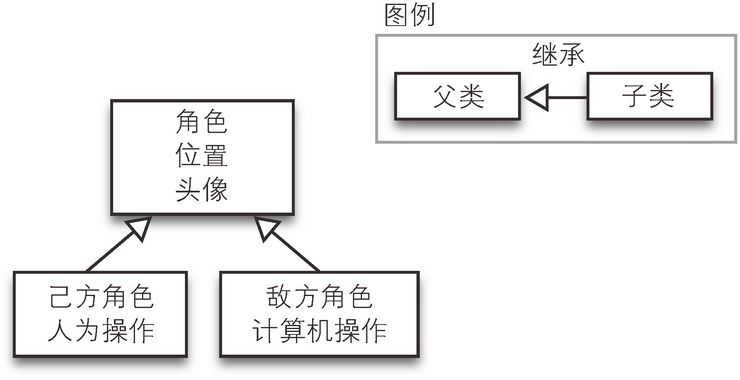

**图 12.1 继承：己方角色和敌方角色都具有位置和头像属性**

如能使用继承实现方式的功能，那编程实现不就变得轻松很多吗？出于这种考虑，继承的使用变得广泛起来。同样是继承，考虑问题的方法和使用方式不尽相同。

### **继承的不同实现策略**

继承的实现策略大体可以分为三种。

#### **一般化与专门化**

第一种策略是在父类中实现那些一般化的功能，在子类中实现那些专门的个性化的功能（图 12.2）。其设计方针就是子类是父类的专门化。在更细致的层面上，它和分类意义是相近的，这和 class＝分类的想法一致。它让人很自然地意识到子类就是父类的一种。

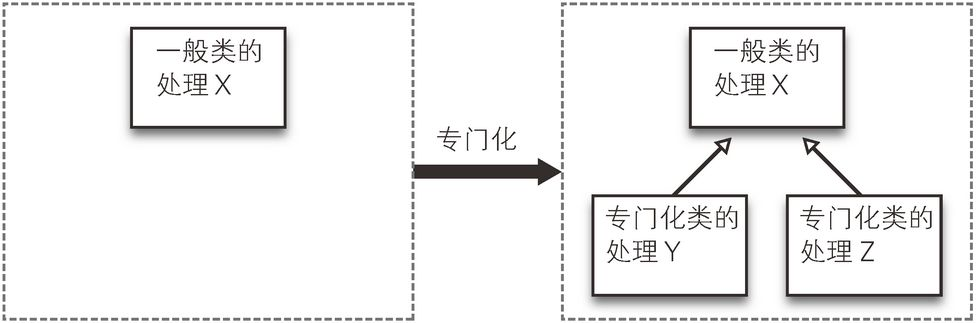

**图 12.2 对一般类的专门化**

#### **共享部分的提取**

第二种策略是从多个类中提取出共享部分作为父类（图 12.3）。它和一般化与专门化的考虑很不一样。对于子类是否为父类的一种，它的答案是否定的。这种提取出共享部分的设计方针是习惯了函数的一种考虑问题的方法。

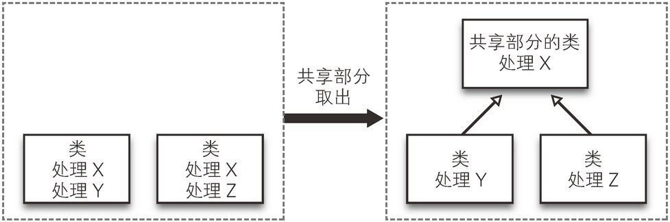

**图 12.3 从多个类中提取共享部分**

#### **差异实现**

第三种策略认为继承之后仅实现有变更的那些属性会带来效率的提高（图 12.4）。它把继承作为实现方式再利用的途径，旨在使编程实现更加轻松。的确有很多这样的情况。但这些情况下通常子类都不是父类的一种。

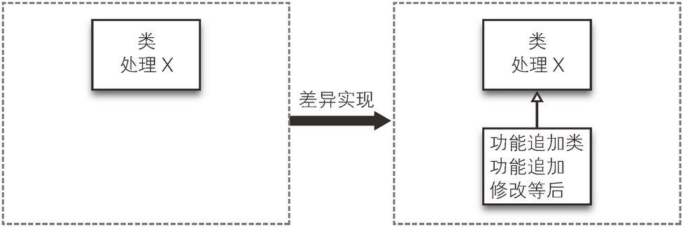

**图 12.4 继承已有的类并实现差异部分**

### **继承是把双刃剑**

使用方法多意味着继承这种机制有很高的自由度。这和我们在第 4 章中接触到的 goto 语句有点类似。滥用 goto 语句可能造成代码理解困难，因此对其使用应加以限制。与此类似，对继承的使用也有相同的考虑，应该对其加以限制。尤其是第三种使用方法——继承已有的类并实现差异部分，这种编程风格会造成多层级的继承树，很容易导致代码理解困难。

多层级的继承树是如何导致代码理解困难的呢？假设某个对象具有方法 X，这一方法的定义在哪里呢？在这个类中，它的父类中，还是它的父类的父类中？要知道答案就需要追溯继承关系检查多个类 2。此外，如果你要修改某个方法，这将影响到所有的子类，以及所有子类的子类。影响范围越广，就越难确定这种修改会不会带来什么问题 3。

2现在有很多集成开发环境都可以承担这种繁重的任务，这说明为使编程这项工作更加轻松，相关工具也得到了进化。

3这个问题不是单靠在程序设计上下工夫就能解决的，同时也可以把大量的检查工作交给计算机去完成来帮助解决，这叫回归测试。解决问题的方法总是有很多种。

这个和我们在第七章中谈到的动态作用域的问题非常相似。人的理解能力是有限的，影响范围太大的话就理解不了了。影响范围小理解起来就轻松。通过使用继承实现代码的再利用，对于编写程序来说代码编写量减少了，工作变轻松了。但是反复使用继承后代码的影响范围便变大了，理解起来也困难了。因此，为了保证理解的简易性，就要防止继承树的层级过多。

### **里氏置换原则**

在第 6 章我们提到过 CLU 语言，它的设计者芭芭拉·利斯科夫（Barbara Liskov）等人在 1987 年提出一种原则——里氏置换原则，这一原则现在常常在创建子类时作为注意点被提及。

这个原则可以表述为：假设对于 T 类型的对象 x，属性 q(x) 恒为真。如果 S 为 T 的派生类，那么 S 类型的对象 y 的属性 q(y) 也必须恒为真 4。

4芭芭拉·利斯科夫，周以真，“A behavioral notion of subtyping”, *ACM Transactions on Programming Languages and Systems (TOPLAS)*, Vol.16, Issue 6, ACM, 1994, pp.1811-1841.在 1987 年的演说“Data abstraction and hierarchy”中，她们最早提出了这个思想。这里的解说针对的是 1994 年的确定性说法，其原文表述是： “Let ø(x) be a property provable about objects x of type T. Then ø(y) should be provable for objects y of type S where S is a subtype of T.”。

这句话换种表达就是，对于类 T 的对象一定成立的条件，对于类 T 的子类 S 的对象也必须成立 5。

5这里简单化处理把子类和 subtype 等同视之。至少在 C++ 语言和 Java 语言中这样理解应该没有问题。

语言表达可能比较难理解，我们用图来说明（图 12.5）。符合置换原则的情况如图左边所示，类 T 的所有对象都满足条件 q。并且类 T 的 子类类 S 的所有对象都满足条件 q。从图中可以看出 S 是 T 的子集，这是很自然的。

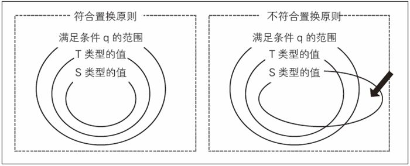

**图 12.5 里氏置换原则**

打破置换原则的情况如图右边所示。箭头指向的部分有不满足条件 q 的 S 类型的值。这边 S 不是 T 的子集。比如在 Java 语言中，如果 S 是 T 的子类，那么可以将类 S 的对象传递给类 T 的类型的变量。即在类型系统中 S 是 T 的子集。然而在现实情况中，最初所有的 T 都满足条件 q，但 S 继承了 T 之后就出现了不满足条件 q 的类 T。因此，为了保证类的继承关系和类型的父子关系这两种关系之间的一致性，有必要遵守这一原则。

这一原则也可以表达为继承必须是 is-a 关系。把子类 S 的所有对象都看作是父类 T 的对象而不会有任何问题，必须要做到这一点。

这一约束条件是非常严格的。当要继承某种类时，需要考虑该类是否可以被继承。假设继承的时候考虑的属性可以使里氏置换原则成立。但是在随后的程序编写过程中，需要的属性可能会越来越多。随着属性的增加，置换原则就有可能被打破。是在设计阶段就把所有属性列出来，只有当置换原则绝对不被打破时才去继承呢？还是在开发阶段如果发现新的属性就放弃类的继承呢？不管哪种方式都很费劲。

## **12.2 多重继承**

我们了解了保证类的继承和类型的机制之间的一致性的难处。类型相当于我们在第 11 章中学习的类的三种作用之中的可行操作的功能说明。

另一方面，发挥类作为代码再利用单元的作用时，类型和类就是分类这种观点有时具有适得其反的效果。尤其对于动态类型语言这样不太重视类型的语言。

本节我们将深入探讨使用类来实现代码再利用的方法。

### **一种事物在多个分类中**

把文件放进不同文件夹进行整理时，常常会有这个或者那个文件该放入哪个文件夹的烦恼。这是因为现实世界中的物并不仅仅属于某一种分类。

举个具体的例子，假设要把公司职员进行分类。把公司职员这个类的元素（即职员）进行分类，定义程序员类，同时也定义不同岗位的业务员类。如果说业务部的职员小李也会编写程序，那究竟该把小李放入程序员类还是业务员类呢？

一个人同时承担程序员和业务员的角色的情况是完全有可能的。那么一个类同时作为多个类的子类的情况就是很自然的了。也就是说现实世界中一种事物有可能属于多种分类。为了实现对这种现实情况的模拟，作为工具的程序设计语言是不是应该支持对多个类的继承呢？这就是多重继承的初衷。

### **多重继承对于实现方式再利用非常便利**

多重继承对于实现方式再利用是一种非常便利的方法。图 12.6 展示的就是多重继承的一个例子。带有菜单栏的窗口这种类继承了窗口类并且实现了菜单栏的操作。另外，带有滚动栏的窗口类也继承了窗口类，并且实现了能滚动内容的滚动栏的功能。如果要实现一种既具有菜单栏又具有滚动栏的窗口该怎么做呢？在支持多重继承的语言中，只需要继承两个类就可以实现。

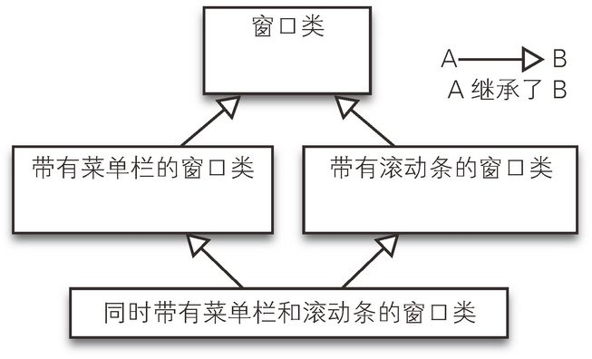

**图 12.6 GUI 和多重继承**

另外，作为实际使用的代码的一个例子，我们来看从 Python 语言标准库 SocketServer.py 中取出的四行代码。

```
 Python标准库中使用的多重继承示例
class ForkingUDPServer(ForkingMixIn, UDPServer): pass
class ForkingTCPServer(ForkingMixIn, TCPServer): pass
class ThreadingUDPServer(ThreadingMixIn, UDPServer): pass
class ThreadingTCPServer(ThreadingMixIn, TCPServer): pass
```

这段代码定义了四个子类，用来表示在通信中使用 UDP 还是 TCP 以及并行处理中使用 fork 还是 thread。这四个子类是由两个选项结合两个类做多重继承定义的（图 12.7）。pass 一词的意思是没有特殊的处理。比如定义 ForkingUDPServer 只需要继承 ForkingMixIn 和 UDPServer 就可以完成，不需要其他的代码。

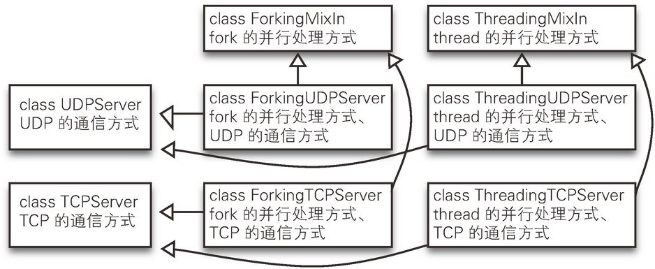

**图 12.7 Python 标准库中使用的多重继承**

## **12.3 多重继承的问题——还是有冲突**

多重继承看起来真的很方便。但是，使用多重继承时该如何解决名字解释的问题呢？当问到类中 x 值是什么时，该如何回答呢？

首先，如果这个类本身知道答案，就直接给出回答（图 12.8）。

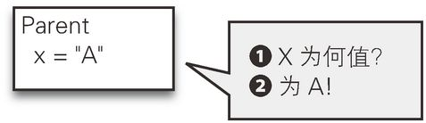

**图 12.8 名字解释之 1**

其次，如果这个类本身不知道答案，就去问它的父类再给出回答（图 12.9）。

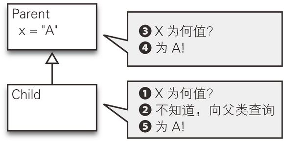

**图 12.9 名字解释之 2**

那么，像下面的代码中展现的多个父类具有相同名字的方法时会怎么样呢？

```
 Python
class ParentA:
    x = "A"

class ParentB:
    x = "B"

class Child(ParentA, ParentB):
    pass

print Child.x  # 正确输出是什么？
```

究竟应该调用哪个方法呢？这里再一次出现了名字解释的问题（图 12.10）。

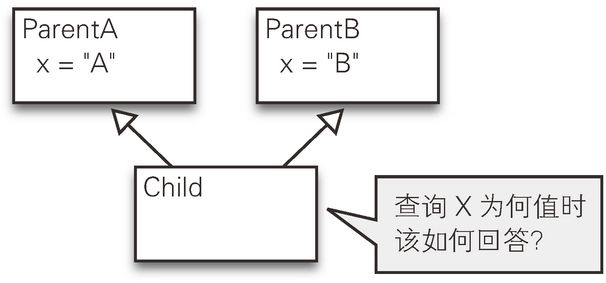

**图 12.10 名字解释之 3**

### **解决方法 1：禁止多重继承**

Java 语言中就禁止了类的多重继承。只要不认可类的多重继承这种方式，就不会有上述问题。这样可以把问题解决得很干脆，只是会以失去多重继承的良好便利性为代价。

除此之外，在 Java 语言及其相关库中也可以观察到舍弃作为实现方式再利用的继承的倾向。比如图形工具套装的实现就是这样。1995 年发布的 Abstract Window Toolkit（AWT）中，它是通过继承对各种方法进行重载的。而现在在 Eclipse 等语言中使用的 Standard Widget Toolkit（SWT）却不允许再使用继承。

#### **委托**

取而代之发展起来的概念是委托 6。这种方法定义了具有待使用实现方式的类的对象，然后根据需要使用该对象来处理。使用继承后，从类型到命名空间都会被一起继承，从而导致问题的发生，这种方法只是停留在使用对象的层面上。

6委托（delegation）也叫做聚集（aggregation）或者咨询（consultation）。

下面一段代码显示了一个使用委托的例子。

```
 Java
public class TestDelegate {
    public static void main(String[] args){
        new UseInheritance().useHello(); // -> hello!
        new UseDelegate().useHello();    // -> hello!
    }
}


class Hello{   ❶
    public void hello(){
        System.out.println("hello!");
    }
}

class UseInheritance extends Hello {   ❷
    public void useHello(){
        hello();                       ❸
    }
}

class UseDelegate {                    ❹
    Hello h = new Hello();             ❺
    public void useHello(){
        h.hello();                     ❻
    }
}
```

显示“Hello ！”的方法 hello 为类 Hello 所持有（❶）。类 UseInheritance 通过继承类 Hello 自身也持有了方法 hello（❷）并加以使用（❸）。与之不同，类 UseDelegate 并没有继承类 Hello（❹），而是通过句❺持有了类 Hello 的对象。当有需要使用时通过句❻将需要的处理委托给该对象操作。

与从多个类中继承实现强耦合的方式相比，使用委托进行耦合的方式显然要更好一些。对于委托的使用，也不需要在源代码中写死，而是可以通过配置文件在合适的时候注入运行时中去。这个想法催生了依赖注入（Dependency Injection）的概念。

#### **接口**

刚刚提到 Java 语言中禁止了多重继承，但它也具备实现多重继承的功能。这就需要借助接口（interface）7。

7Java 语言中类的继承用 extends，接口的继承用 implements 来区别表示。另外接口的继承也称为实现。

接口是没有实现方式的类。它的功能仅仅在于说明继承了该接口的类必须持有某某名字的方法。多重继承中发生的问题是多种实现方式相冲突时选取哪个的问题。而在接口的多重继承中，尽管有多个持有某某方法的信息存在，但这仅仅表明持有某某方法，不会造成任何困扰。下面一段代码中就继承了持有相同名字的方法的两个类，编译时不会发生错误 8。

8Java 语言中可以对名字相同但参数类型不同的方法进行重载。因此，准确来讲， 这里说的名字应该是签名。

```
 Java
public class TestMultiImpl implements Foo, Bar {
    public void hello(){
        System.out.println("hello!");
    }
}

interface Foo {
    public void hello();
}

interface Bar {
    public void hello();
}
```

这段代码中，类 TestMultiImpl 继承了 Foo 和 Bar 两个接口。如果这个类中不实现 public void hello ()，编译时将出现“没有实现应该实现的方法”这样的错误 9。也就是说，继承了接口 Foo 后，这个类就作为一种类型表现出必须持有 public void hello () 的特点，可以让编译器对它进行类型检查。

9具体来讲，提示的错误消息应该是“TestMultiImpl 不是 abstract 的，Foo 中 的 abstract 方法 hello( ) 没有被重载”。

Java 语言为了仅实现功能上的多重继承引入了接口。PHP 语言和 Java 语言一样不认可多重继承，并从 2004 年发布的 PHP5 开始引入了接口的概念。

### **解决方法 2：按顺序进行搜索**

曾经也有些语言试图通过明确定义搜索顺序来解决冲突问题。但是该如何定义呢？如果单纯定义说当前类回答不了时就去检查首先书写的（左边的）类，按这样的顺序（深度优先搜索法）可行吗？（图 12.11）

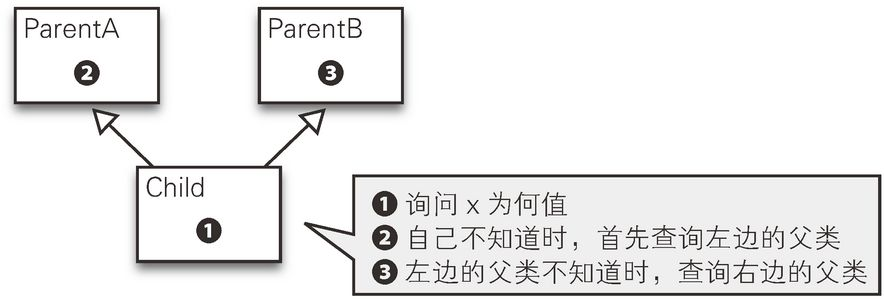

**图 12.11 从左边开始搜索的顺序**

#### **深度优先搜索法的问题**

遗憾的是这种方法可能造成不自然的结果。请看下面的代码。

```
 Python
class Parent:
    x = "A"

class Child(Parent):
    x = "B"

print Child.x   #-> 重载之后变成B

class Base:
    x = "A"

class Derived1(Base):
    pass

class Derived2(Base):
    x = "B"

class Multi(Derived1, Derived2):
    pass

print Multi.x   #-> 该输出何值？
```

从类 Base 继承了两个类 Derived1 和 Derived2。又有一个类 Multi 从这两个类继承出来。这样产生的继承关系叫菱形继承。

方法是可以被重载（override）的。图 12.12 的左边的 Parent 中定义的 x 在 Child 中就被重载了。因此 Child 中的 x 值变成了重载后的值。那么图 12.12 右边的菱形继承中 Derived2 方法重载之后，Multi.x 的值应该是多少呢？

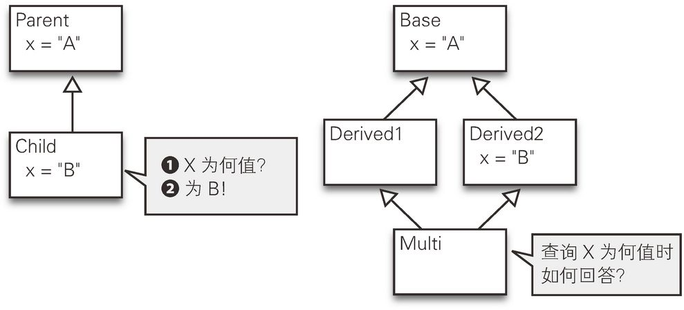

**图 12.12 重载和菱形继承**

Multi 首先检查左边的父类 Derived1，Derived1 再检查它的父类 Base，结果是 A。Python 2.1（2001 年）就是遵循这种方式的（深度优先搜索法）。然而使用这种方法的话，初始的 x 和重载后的 x 混合后的结果仍然是初始的 x。这样一来，好不容易重新定义的 x 丢失了。

为了回避这一问题，从 Python 2.3（2003 年）开始使用 C3 线性化 10。

102001 年发布的 Python 2.2 中引入了一种新风格的类（new-style class），同时决定方法搜索顺序的算法也得到了改良。但是，文档上的理论和实际实现之间有种种差异，几经波折之后，Python 2.3 还是确定采用 C3 线性化。

#### **C3 线性化确定顺序**

C3 线性化是于 1996 年提出来的一种算法 11，它对类进行编号以满足以下两个约束条件：

11在 OOPSLA'96 的活动上，Kim Barrett 等人发表了题为“A Monotonic Superclass Linearization for Dylan”的演讲。

- 父类不比子类先被检查
- 如果是从多个类中继承下来则优先检查先书写的类

之所以出现重载后的值变回初始值，就是因为父类先于子类被检 查。因此，在此有针对性地加上了第一个结束条件（图 12.13）。

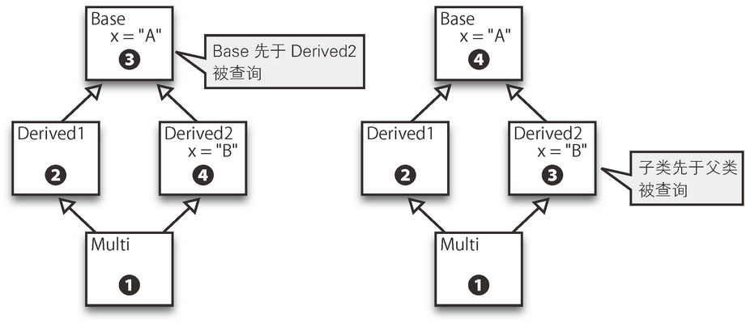

**图 12.13 左：深度优先的搜索顺序 右：C3 线性化的顺序**

下面的代码反映了使用深度优先搜索法的 Python 2.1 和采用了 C3 线性化顺序的 Python 2.3 以后的版本之间程序行为的差别。

```
 Python 2.1
# 尽管在Derived2中对ｘ进行了重新定义
# 到Multi后又回到了原来的情况
class Base:
    x = 'A'

class Derived1(Base): pass

class Derived2(Base):
    x = 'B' # 重新定义

class Multi(Derived1, Derived2): pass # Derived1在左边

print Multi.x #-> 'A'
# ↑没有使用Derived2中的定义

 Python 2.3以降
# new-style class（继承自object，使用C3线性化）
# Derived2中定义的'B'被Multi继承下来了
class Base(object):
    x = 'A'

class Derived1(Base): pass

class Derived2(Base):
    x = 'B' # 重新定义

class Multi(Derived1, Derived2): pass

print Multi.x #->'B'
# ↑使用了Derived2中的定义
```

Perl 语言曾经允许在库的层面交替使用深度优先搜索法、广度优先搜索法 12 和 C3 线性化。从 Perl 6 开始已采用 C3 线性化的方法作为默认的程序行为。

12简单来说，这是一种先将所有直接父类穷尽再去检查父类的父类的搜索方法。

### **解决方法 3：混入式处理**

原本，问题是指从一个类到它的祖先类 13 有多种追溯方法。既然如此，定义仅包含所需功能的类并把它与需要添加这些功能的更大的类糅合在一起不就行了吗？我们把这种设计方针、混入式处理方式和用来混入的小的类统称为混入处理（Mix-in）。据说 14Mix-in 一词起源于 C++ 语言设计者斯特劳斯特卢普经常光顾的 MIT（麻省理工学院）附近的一家甜品屋，指的是把坚果、葡萄干和冰淇淋混合在一起 15。

13祖先类是包括了父类以及父类的父类等的统称。

14请参考斯特劳斯特卢普《C++ 语言的设计与演化》，http://www.stroustrup.com/dne.html。

15笔者也曾去过那家甜品屋吃过冰淇淋，能按自己独特的需求配制出心仪的口味的冰淇淋是件挺有趣的事情。

菱形继承在使用了 Mix-in 之后就可以变形为非菱形继承。图 12.14 的左侧展示的是类 AB 从类 A 继承并添加了方法 B，类 AC 从类 A 继承并添加了方法 C，进而从类 AB 和类 AC 做多重继承得到了类 ABC。右侧展示的是通过从类 A 和做混入处理用的类 B、类 C 按实际需要继承得到类 AB、类 AC、类 ABC。这种方法不仅消除了菱形继承，而且继承树的深度也减少了一层。

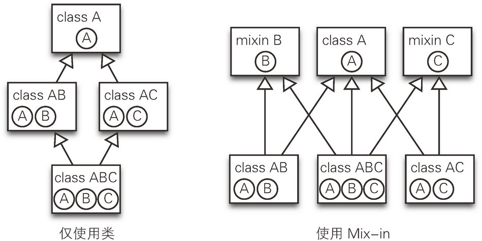

**图 12.14 左：菱形继承 右：使用 Mix-in 消除菱形继承**

#### **Python 语言中**

Mix-in 这种编程风格本身并不依赖于语言处理器，即使不被支持也可以使用。在 12.2 节 SocketServer.py 的多重继承这个例子中，ForkingMixIn 和 ThreadingMixIn 就是为实现混入式多重继承的小型的类。通常这些小型的类最小限度地定义了一些方法，起到了作为代码再利用单位的作用。然而它们却不用于单独创建实例。为了表明这一点，Python 语言会在该类的名字中加上 MixIn 来标识。

#### **Ruby 语言中**

Ruby 语言采用的规则是：类是单一继承的而模块则可以任意数量地做混入式处理。模块无法创建实例，但可以像类一样拥有成员变量和方法。也就是说，模块实质上是从类中去除了实例创建功能。即使类的多重继承被禁止了，通过使用模块的 Mix-In 方式照样可以实现对实现方式的再利用 16。

16Mix-in 并不能解决所有的名字冲突的问题。图 12.14 右侧的类 A 和 mixin B 或者 mixin B 和 mixin C 有相同名字的方法时，仍然会导致冲突的产生。

下面的代码中，模块 Hello 中定义了方法 hello，模块 Bye 中定义了方法 bye，类 Greeting 是这两个类混入式处理的结果。最后两行代码的运行结果证实了 Greeting 的对象同时具有方法 hello 和方法 bye。

```
 Ruby
module Hello
  def hello
    puts "hello!"
  end
end

module Bye
  def bye
    puts "bye!"
  end
end

class Greeting
  include Hello
  include Bye
end

Greeting.new.hello  #-> hello!
Greeting.new.bye    #-> bye!
```